# IP_week13

Stephen Njuguna

1/30/2022

# Customer Groups

## Defining the question

Learn the customer’s behavior and characteristics and group them.

## Defining the metric for success

Being able to sucessfully cluster the customers

## Understanding the context

Understanding consumer behavior is a vital aspect of marketing. Consumer behavior is the study of how people make decisions about what they buy, want, need, or act in regards to a product, service, or company. It also helps companies identify opportunities that are not currently met.

## Experimental design

- Problem Definition
- Data Sourcing
- Check the Data
- Perform Data Cleaning
- Perform Exploratory Data Analysis (Univariate, Bivariate & Multivariate)
- Implement the Solution
- Challenge the Solution

## Read Our Dataset

```r
#Reading the Dataset and preveiwing dataset

customer <- read.csv('http://bit.ly/EcommerceCustomersDataset')

head(customer)
```

```
##   Administrative Administrative_Duration Informational Informational_Duration
## 1              0                       0             0                      0
## 2              0                       0             0                      0
## 3              0                      -1             0                     -1
## 4              0                       0             0                      0
## 5              0                       0             0                      0
## 6              0                       0             0                      0
##   ProductRelated ProductRelated_Duration BounceRates ExitRates PageValues
## 1              1                0.000000  0.20000000 0.2000000          0
## 2              2               64.000000  0.00000000 0.1000000          0
## 3              1               -1.000000  0.20000000 0.2000000          0
## 4              2                2.666667  0.05000000 0.1400000          0
## 5             10              627.500000  0.02000000 0.0500000          0
## 6             19              154.216667  0.01578947 0.0245614          0
##   SpecialDay Month OperatingSystems Browser Region TrafficType
## 1          0   Feb                1       1      1           1
## 2          0   Feb                2       2      1           2
## 3          0   Feb                4       1      9           3
## 4          0   Feb                3       2      2           4
## 5          0   Feb                3       3      1           4
## 6          0   Feb                2       2      1           3
##         VisitorType Weekend Revenue
## 1 Returning_Visitor   FALSE   FALSE
## 2 Returning_Visitor   FALSE   FALSE
## 3 Returning_Visitor   FALSE   FALSE
## 4 Returning_Visitor   FALSE   FALSE
## 5 Returning_Visitor    TRUE   FALSE
## 6 Returning_Visitor   FALSE   FALSE
```

```r
#Checking the data types
str(customer)
```

```
## 'data.frame':    12330 obs. of  18 variables:
##  $ Administrative         : int  0 0 0 0 0 0 0 1 0 0 ...
##  $ Administrative_Duration: num  0 0 -1 0 0 0 -1 -1 0 0 ...
##  $ Informational          : int  0 0 0 0 0 0 0 0 0 0 ...
##  $ Informational_Duration : num  0 0 -1 0 0 0 -1 -1 0 0 ...
##  $ ProductRelated         : int  1 2 1 2 10 19 1 1 2 3 ...
##  $ ProductRelated_Duration: num  0 64 -1 2.67 627.5 ...
##  $ BounceRates            : num  0.2 0 0.2 0.05 0.02 ...
##  $ ExitRates              : num  0.2 0.1 0.2 0.14 0.05 ...
##  $ PageValues             : num  0 0 0 0 0 0 0 0 0 0 ...
##  $ SpecialDay             : num  0 0 0 0 0 0 0.4 0 0.8 0.4 ...
##  $ Month                  : chr  "Feb" "Feb" "Feb" "Feb" ...
##  $ OperatingSystems       : int  1 2 4 3 3 2 2 1 2 2 ...
##  $ Browser                : int  1 2 1 2 3 2 4 2 2 4 ...
##  $ Region                 : int  1 1 9 2 1 1 3 1 2 1 ...
##  $ TrafficType            : int  1 2 3 4 4 3 3 5 3 2 ...
##  $ VisitorType            : chr  "Returning_Visitor" "Returning_Visitor" "Returning_Visitor" "Returning_Visitor" ...
##  $ Weekend                : logi  FALSE FALSE FALSE FALSE TRUE FALSE ...
##  $ Revenue                : logi  FALSE FALSE FALSE FALSE FALSE FALSE ...
```

```r
#Checking data dimension
dim(customer)
```

```
## [1] 12330    18
```

## Data Cleaning

```r
#Checking for missing values
colSums(is.na(customer))
```

```
##          Administrative Administrative_Duration           Informational
##                      14                      14                      14
##  Informational_Duration          ProductRelated ProductRelated_Duration
##                      14                      14                      14
##             BounceRates               ExitRates              PageValues
##                      14                      14                       0
##              SpecialDay                   Month        OperatingSystems
##                       0                       0                       0
##                 Browser                  Region             TrafficType
##                       0                       0                       0
##             VisitorType                 Weekend                 Revenue
##                       0                       0                       0
```

```r
#Dealing with the missing values
customer <- na.omit(customer)

#Dropping all the missing value because they are a very few caparisoning to
# the number of rows we have
```

```r
#Checking for duplicates and dealing with duplicates if any

customer <- unique(customer)
```

```r
#Checking for outliers
#slecting only numeric columns
library(dplyr)
```

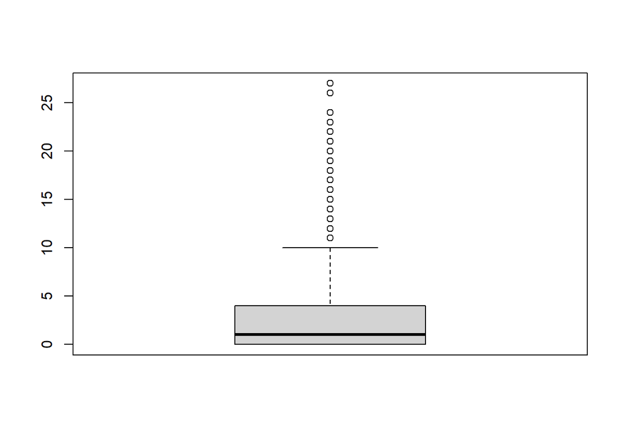

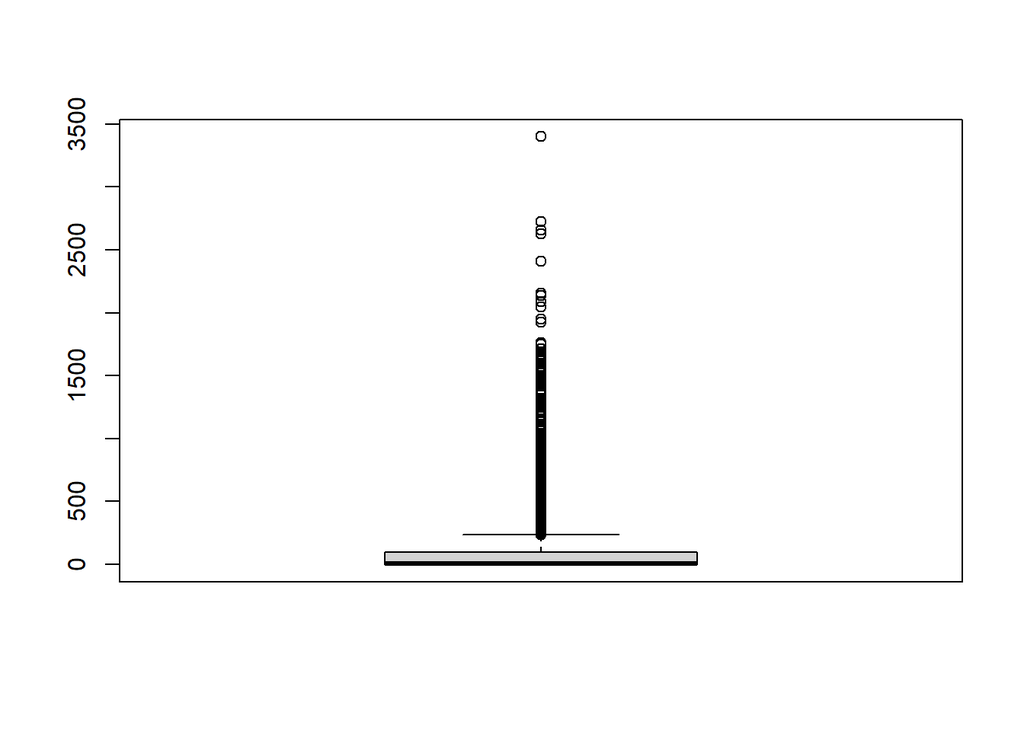

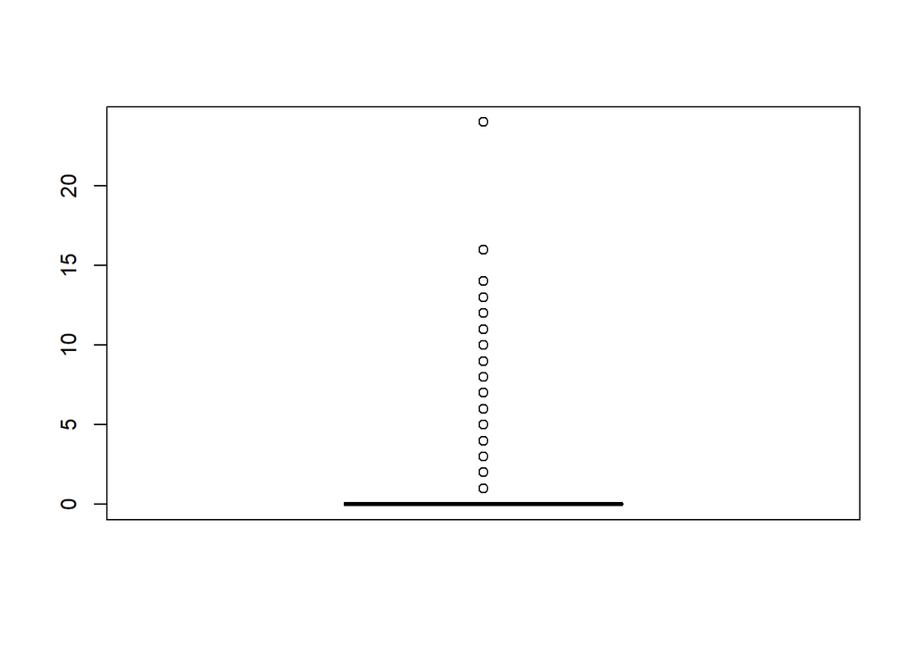

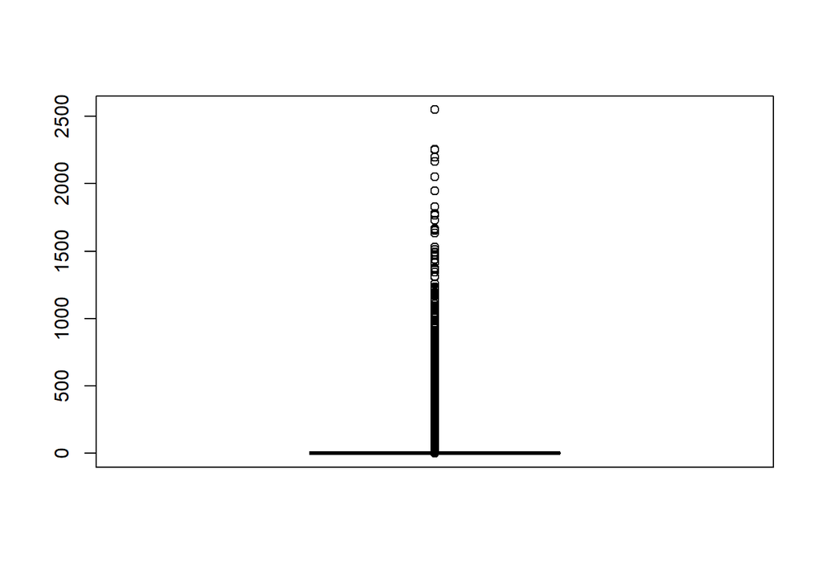

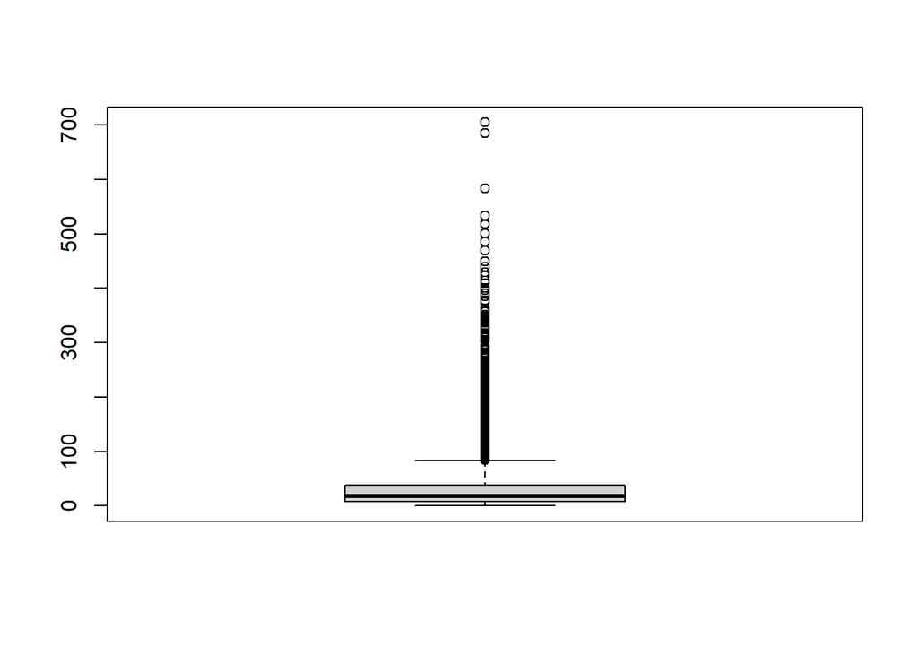

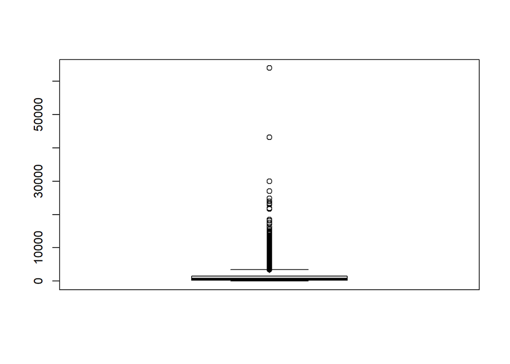

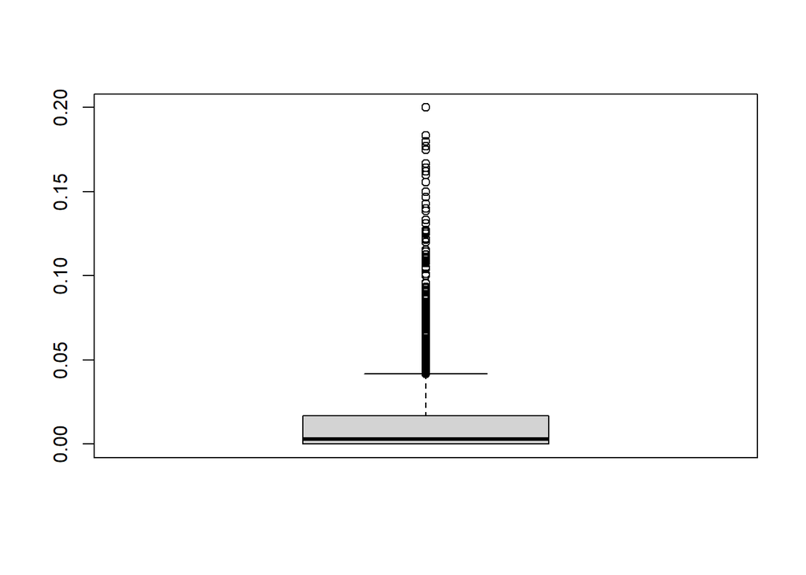

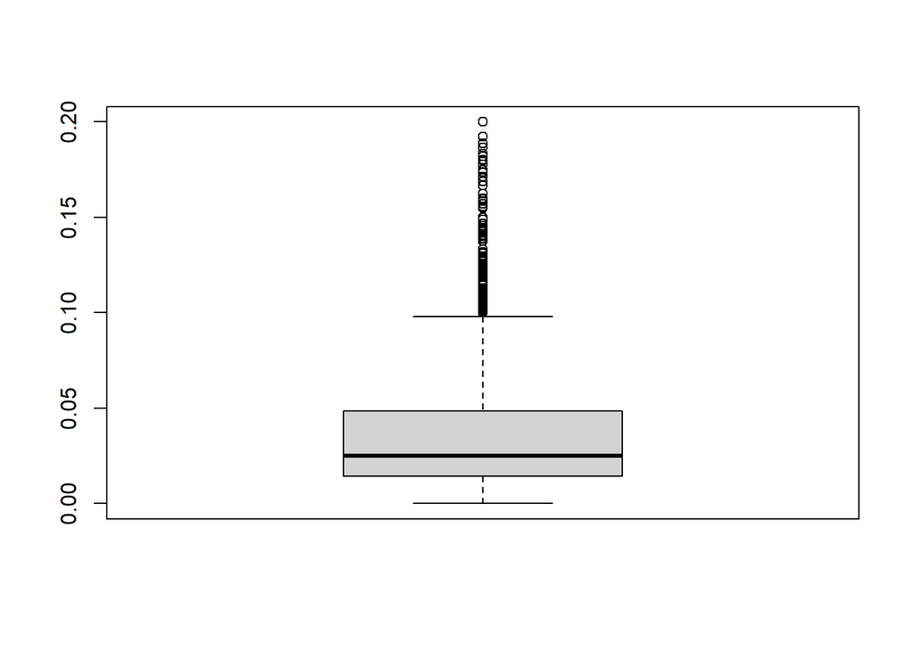

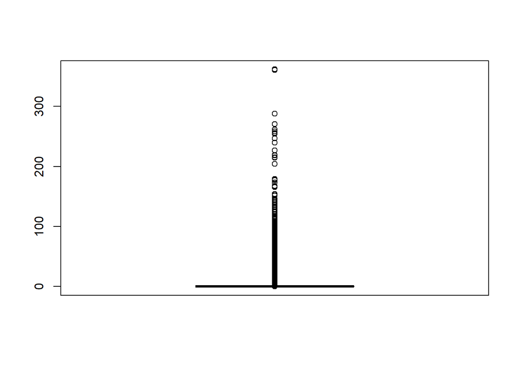

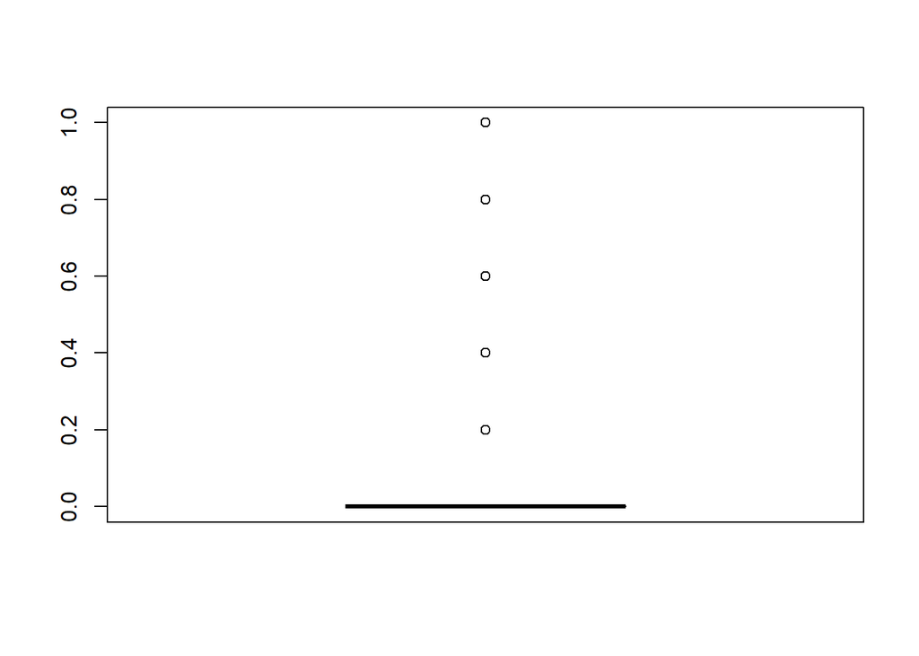

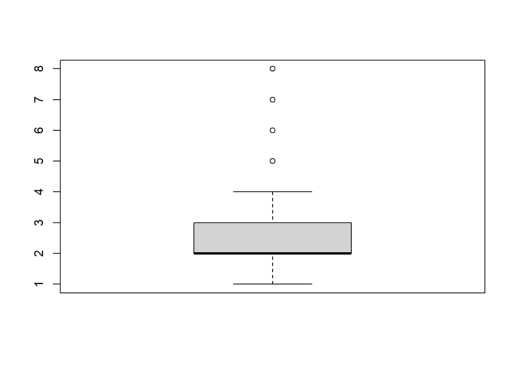

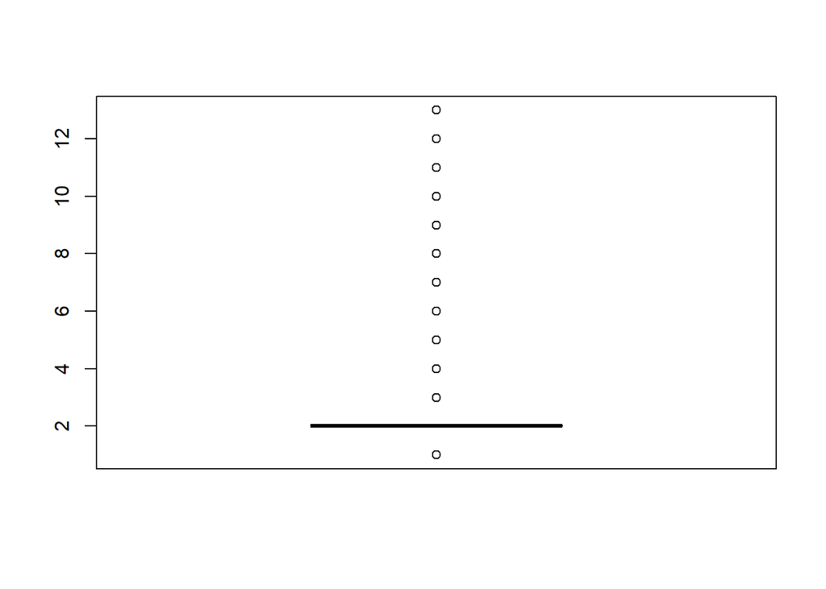

[2 more figures not shown]

```r
numeric <- select_if(customer, is.numeric)

#ploting box plots
invisible(lapply(1:ncol(numeric), function(i) boxplot(numeric[, i])))
```

## Exploratory Data Analysis

### Univeriate Analysis

```r
#Check statistical summary of data
summary(numeric)
```

```
##  Administrative  Administrative_Duration Informational
##  Min.   : 0.00   Min.   :  -1.00         Min.   : 0.0000
##  1st Qu.: 0.00   1st Qu.:   0.00         1st Qu.: 0.0000
##  Median : 1.00   Median :   9.00         Median : 0.0000
##  Mean   : 2.34   Mean   :  81.68         Mean   : 0.5088
##  3rd Qu.: 4.00   3rd Qu.:  94.75         3rd Qu.: 0.0000
##  Max.   :27.00   Max.   :3398.75         Max.   :24.0000
##  Informational_Duration ProductRelated   ProductRelated_Duration
##  Min.   :  -1.00        Min.   :  0.00   Min.   :   -1.0
##  1st Qu.:   0.00        1st Qu.:  8.00   1st Qu.:  193.6
##  Median :   0.00        Median : 18.00   Median :  609.5
##  Mean   :  34.84        Mean   : 32.06   Mean   : 1207.5
##  3rd Qu.:   0.00        3rd Qu.: 38.00   3rd Qu.: 1477.6
##  Max.   :2549.38        Max.   :705.00   Max.   :63973.5
##   BounceRates        ExitRates         PageValues        SpecialDay
##  Min.   :0.00000   Min.   :0.00000   Min.   :  0.000   Min.   :0.00000
##  1st Qu.:0.00000   1st Qu.:0.01422   1st Qu.:  0.000   1st Qu.:0.00000
##  Median :0.00293   Median :0.02500   Median :  0.000   Median :0.00000
##  Mean   :0.02045   Mean   :0.04150   Mean   :  5.952   Mean   :0.06197
##  3rd Qu.:0.01667   3rd Qu.:0.04848   3rd Qu.:  0.000   3rd Qu.:0.00000
##  Max.   :0.20000   Max.   :0.20000   Max.   :361.764   Max.   :1.00000
##  OperatingSystems    Browser           Region       TrafficType
##  Min.   :1.000    Min.   : 1.000   Min.   :1.000   Min.   : 1.000
##  1st Qu.:2.000    1st Qu.: 2.000   1st Qu.:1.000   1st Qu.: 2.000
##  Median :2.000    Median : 2.000   Median :3.000   Median : 2.000
##  Mean   :2.124    Mean   : 2.358   Mean   :3.153   Mean   : 4.075
##  3rd Qu.:3.000    3rd Qu.: 2.000   3rd Qu.:4.000   3rd Qu.: 4.000
##  Max.   :8.000    Max.   :13.000   Max.   :9.000   Max.   :20.000
```

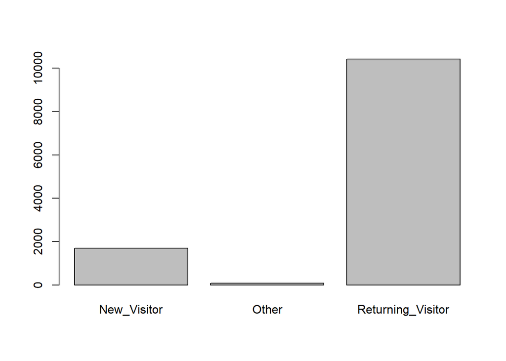

```r
#Plotting Visitor ype
v_type <- table(customer$VisitorType)
barplot(v_type)
```

Most of the customer are the returning_visitors.

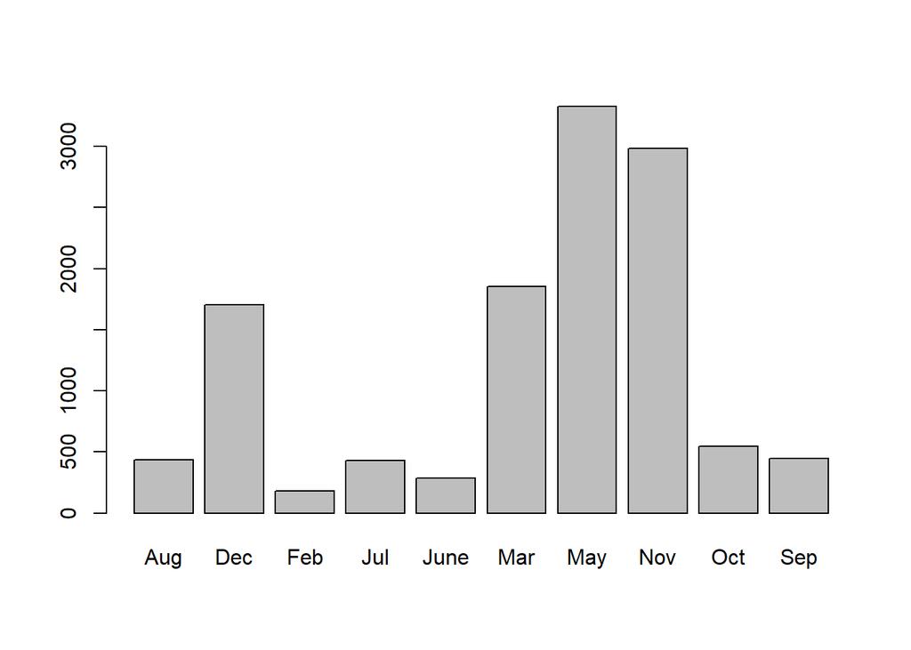

```r
#Plotting month
month <- table(customer$Month)
barplot(month)
```

Most customers visit the e-commerce site on the month of May followed by November. The month with the least visits in February

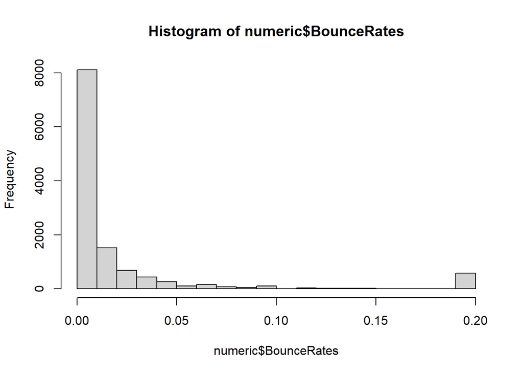

```r
#Plotting the customers Bounce rate
hist(numeric$BounceRates)
```

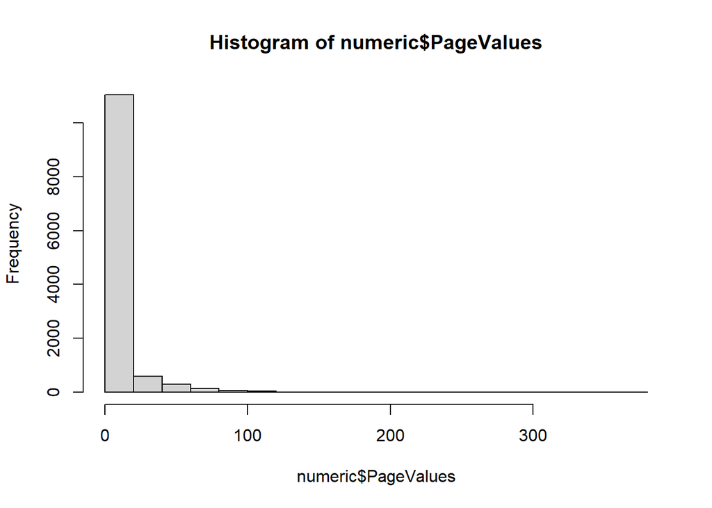

```r
#Plotting the page value
hist(numeric$PageValues)
```

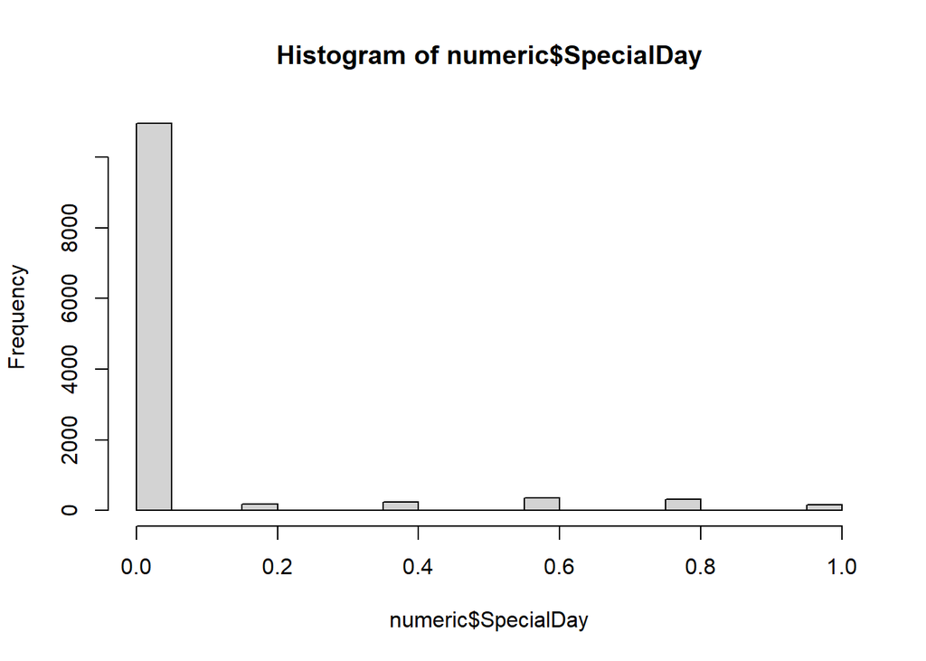

```r
#Plotting the special day column
hist(numeric$SpecialDay)
```

Most people visit before or after the special day.

## Biavariate Analysis

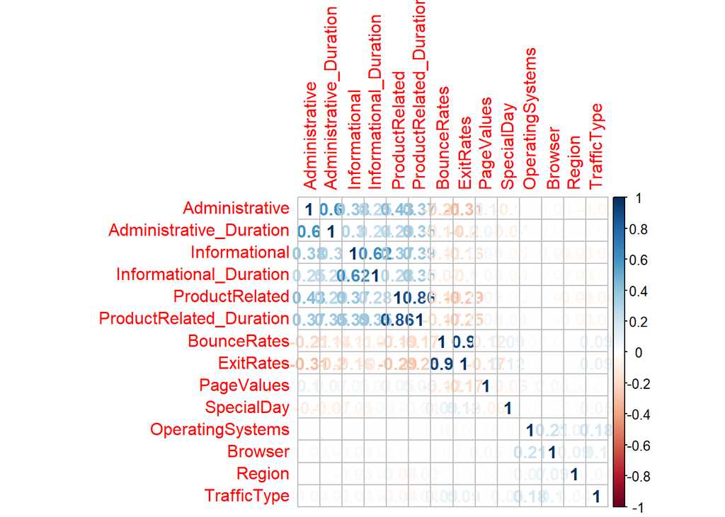

```r
#Plotting a correlation plot
corr<-cor(numeric)
corrplot::corrplot(corr, method="number")
```

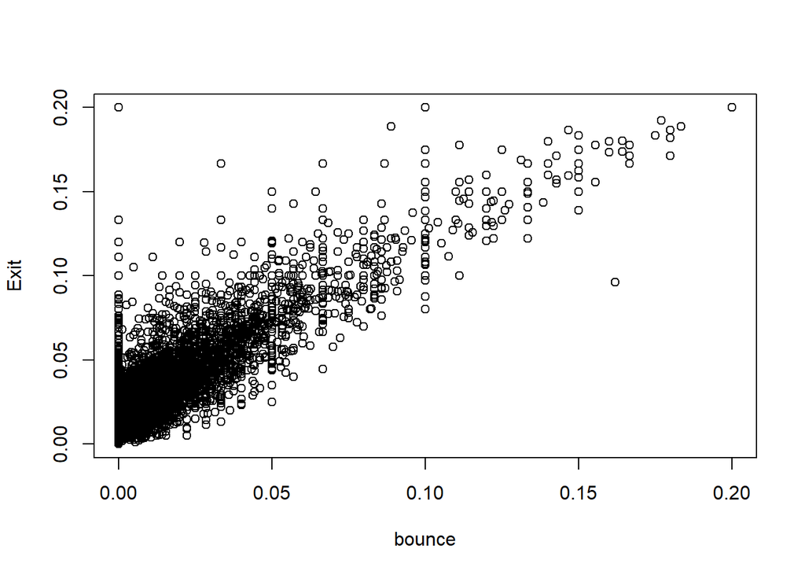

```r
#Plotting a scatter plot between bounce and exit rate
bounce <- numeric$BounceRates
exit <- numeric$ExitRates
plot(bounce, exit, xlab="bounce", ylab="Exit")
```

There is strong correlation between bounce and exit rate

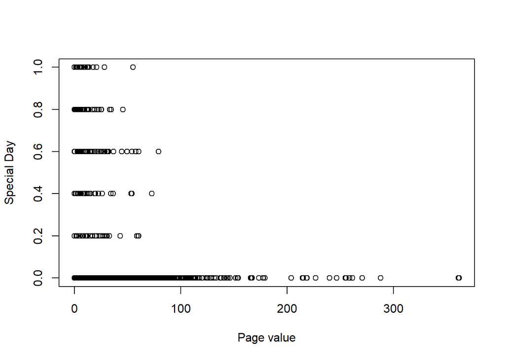

```r
#Plotting scatter plot between page value and special day
value <- numeric$PageValues
day<- numeric$SpecialDay
plot(value, day, xlab="Page value", ylab="Special Day")
```

## Multivariate Analysis

```r
#Label econding categorical columns to numeric
customer$VisitorType <- as.numeric(factor(customer$VisitorType))
customer$Weekend <- as.numeric(factor(customer$Weekend))
customer$Region <- as.numeric(factor(customer$Region))
customer$Revenue <- as.numeric(factor(customer$Revenue))
customer$Month <- as.numeric(factor(customer$Month))
```

```r
custm <- customer[c(-18)]
#Performing dimension reduction using PCA
dim_customer <- prcomp(custm,scale. = FALSE)

summary(dim_customer)
```

```
## Importance of components:
##                              PC1       PC2      PC3      PC4      PC5   PC6
## Standard deviation     1921.9742 168.26488 129.7356 22.72821 18.59466 4.024
## Proportion of Variance    0.9877   0.00757   0.0045  0.00014  0.00009 0.000
## Cumulative Proportion     0.9877   0.99526   0.9998  0.99990  0.99999 1.000
##                          PC7   PC8   PC9  PC10   PC11   PC12   PC13   PC14
## Standard deviation     2.476 2.434 2.333 1.692 0.9423 0.8659 0.6798 0.4219
## Proportion of Variance 0.000 0.000 0.000 0.000 0.0000 0.0000 0.0000 0.0000
## Cumulative Proportion  1.000 1.000 1.000 1.000 1.0000 1.0000 1.0000 1.0000
##                          PC15    PC16    PC17
## Standard deviation     0.1967 0.05838 0.01344
## Proportion of Variance 0.0000 0.00000 0.00000
## Cumulative Proportion  1.0000 1.00000 1.00000
```

## Modeling

### Heirarchical clustering

```r
#Scale the dataset
scaled.custm <- scale(custm)
```

```r
## Calculate the (Euclidean) distances
hist.custm <- dist(scaled.custm)
```

```r
## Create a hierarchical clustering model
clust.custm <- hclust(hist.custm, method = 'complete')
```

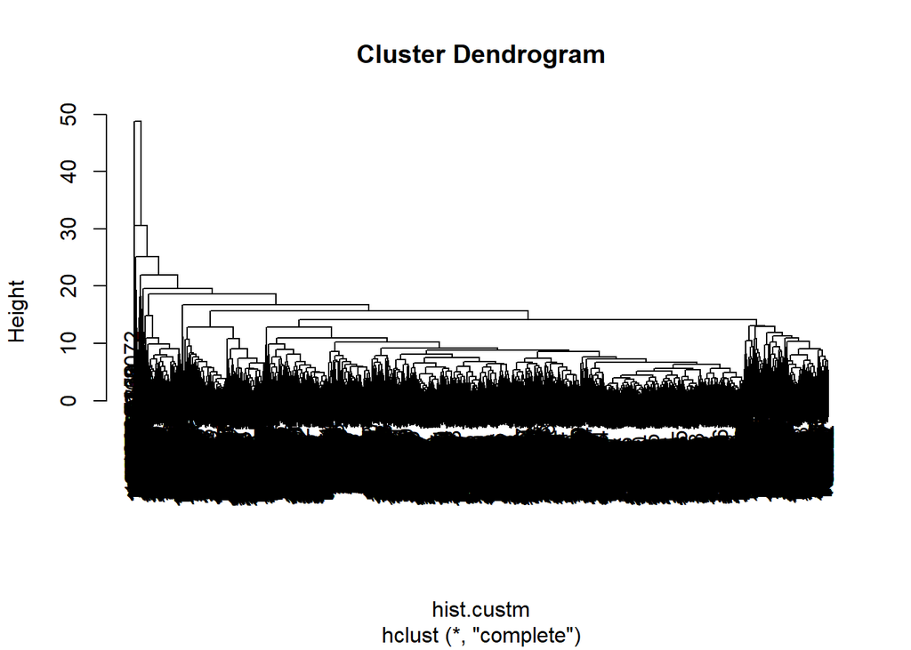

```r
#Plot (Dendrogram) the clusters to get height
plot(clust.custm)
```

```r
## Cut tree so that it has 2 clusters:
custm.clusters <- cutree(clust.custm, k = 2)
```

```r
# Compare heirarchical cluster to actual clusters
table(custm.clusters)
```

```
## custm.clusters
##     1     2
## 12196     3
```

```r
table(customer$Revenue)
```

```
##
##     1     2
## 10291  1908
```

Hierarchical cluster ,groups 1’s as 12196 compared to the actual of 10291 and group 2’s as 3 compared to the actual group of 1908

### k-means clustering

```r
#Normalization of the data
normal <- function(x) (
  return( ((x - min(x)) /(max(x)-min(x))) )
)
normal(1:18)
```

```
##  [1] 0.00000000 0.05882353 0.11764706 0.17647059 0.23529412 0.29411765
##  [7] 0.35294118 0.41176471 0.47058824 0.52941176 0.58823529 0.64705882
## [13] 0.70588235 0.76470588 0.82352941 0.88235294 0.94117647 1.00000000
```

```r
nom.custm<- as.data.frame(lapply(customer[,-18], normal))
```

```r
# Create a k-means model on
custm.km <- kmeans(nom.custm, centers = 2, nstart = 20)
```

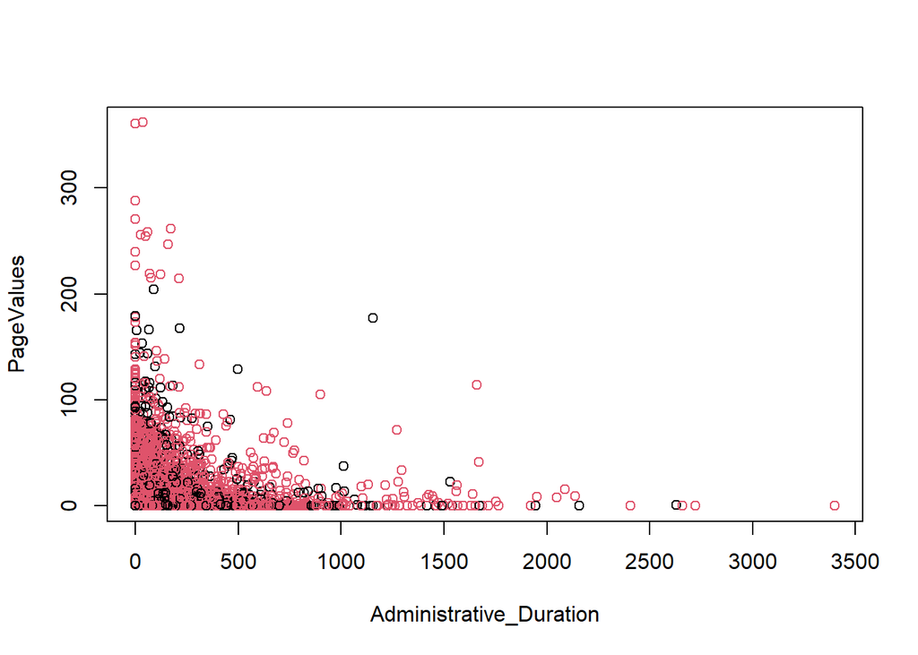

```r
#Plotting the clusters
plot(custm[c(2,9)], col = custm.km$cluster)
```

```r
# Compare k Mean cluster to actual clusters
table(custm.km$cluster)
```

```
##
##    1    2
## 2856 9343
```

```r
table(customer$Revenue)
```

```
##
##     1     2
## 10291  1908
```

K Mean cluster ,groups 1’s as 2856 compared to the actual of 10291 and group 2’s as 9343 compared to the actual group of 1908

### Comparisons between K-Means clustering vs Hierarchical

```r
# Compare hierarchical clustering to k-means
table(custm.clusters)
```

```
## custm.clusters
##     1     2
## 12196     3
```

```r
table(custm.km$cluster)
```

```
##
##    1    2
## 2856 9343
```

## Conclusion

K mean clustering performance much better compared to Hierarchical clustering.

- K mean cluster works better than hierarchical clustering when it come to large datasets , which in our case we had a large dataset.
- K Means clustering needed advance knowledge of no. of clusters one want to divide your data compared to hierarchical cluster which finds appropriate by interpreting the dendrogram. In our case we have knowledge of the number of clusters.
- K mean clustering is very sensitive to outliers because when you have outliers, this can affect the average calculation of the whole cluster.